# Analysing the adoption and Growth of Bitcoin in relation to scarcity

*Choosing the CSV File:*

```r
sfdata <- read.csv(choose.files())
```

```r
install.packages("lmtest")
```

```r
library(car)
library(tseries)
library(sandwich)# needed to produce heteroskedastic consistent standard errors
library(lmtest) # needed for Breusch Pagan Test - alternative to White's test
```

```r
attach(sfdata)
```

```r
summary(sfdata)
```

```
     Date               blocks          btc             stockflow         price
 Length:105         Min.   :3749   Min.   : 3571800   Min.   : 0.50   Min.   :    0.1
 Class :character   1st Qu.:4465   1st Qu.:10065500   1st Qu.: 3.10   1st Qu.:   12.7
 Mode  :character   Median :4649   Median :13567775   Median : 9.10   Median :  372.5
                    Mean   :4819   Mean   :12672594   Mean   :11.23   Mean   : 1600.9
                    3rd Qu.:5030   3rd Qu.:16129550   3rd Qu.:21.30   3rd Qu.: 1070.0
                    Max.   :7875   Max.   :17612600   Max.   :28.10   Max.   :13863.0
   market_cap        active_addresses    log_price      log_stockflow     log_active_addresses
 Min.   :2.324e+05   Min.   :    401   Min.   :-2.303   Min.   :-0.6931   Min.   : 5.994
 1st Qu.:1.147e+08   1st Qu.:  34731   1st Qu.: 2.542   1st Qu.: 1.1314   1st Qu.:10.455
 Median :5.101e+09   Median : 191798   Median : 5.920   Median : 2.2083   Median :12.164
 Mean   :2.659e+10   Mean   : 304818   Mean   : 5.067   Mean   : 2.0209   Mean   :11.609
 3rd Qu.:1.555e+10   3rd Qu.: 574760   3rd Qu.: 6.975   3rd Qu.: 3.0587   3rd Qu.:13.262
 Max.   :2.320e+11   Max.   :1116245   Max.   : 9.537   Max.   : 3.3358   Max.   :13.925
   log_blocks    log_market_cap       fits            fits2             fits3
 Min.   :8.229   Min.   :12.36   Min.   :-3.043   Min.   : 0.0311   Min.   :-28.18
 1st Qu.:8.404   1st Qu.:18.56   1st Qu.: 3.061   1st Qu.: 9.3719   1st Qu.: 28.69
 Median :8.444   Median :22.35   Median : 5.725   Median :32.7714   Median :187.60
 Mean   :8.474   Mean   :21.34   Mean   : 5.067   Mean   :34.1146   Mean   :235.38
 3rd Qu.:8.523   3rd Qu.:23.47   3rd Qu.: 7.783   3rd Qu.:60.5783   3rd Qu.:471.49
 Max.   :8.971   Max.   :26.17   Max.   : 8.323   Max.   :69.2654   Max.   :576.47
   residuals2
 Min.   :0.000002
 1st Qu.:0.106030
 Median :0.430188
 Mean   :0.629048
 3rd Qu.:0.824415
 Max.   :5.041546
```

- Ploting a simple relationship between vairables with price as a dependent variable and stockflow and market-cap as independent vairables: *

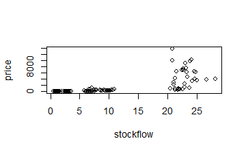

```r
plot(price ~ stockflow, data = sfdata)
```

- Converting the values into log in order to remove the inconsistencies: *

```r
sfdata$log_price <- log(sfdata$price)
sfdata$log_stockflow <- log(sfdata$stockflow)
sfdata$log_active_addresses<-log(sfdata$active_addresses)
sfdata$log_blocks <- log(sfdata$blocks)
sfdata$log_market_cap <- log(sfdata$market_cap)
```

- Ploting after conversion to see the relationship between variables: *

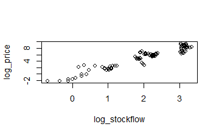

```r
plot(log_price ~ log_stockflow, data = sfdata)
```

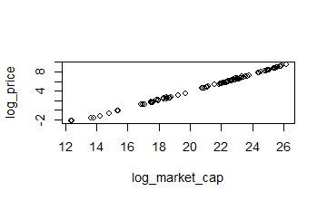

```r
plot(log_price ~ log_market_cap, data = sfdata)
```

- Plotting to test the Hypothesis using SIMPLE LINEAR REGRESSION: *

*Fitting the linear regression model to predict the behavior of price and stock flow ratio to test the hypothesis 1:*

```r
lnmodel<- lm(log_price ~ log_stockflow, data = sfdata)
summary(lnmodel)
```

```
Call:
lm(formula = log_price ~ log_stockflow, data = sfdata)

Residuals:
     Min       1Q   Median       3Q      Max
-2.43945 -0.54211 -0.01769  0.50870  2.48403

Coefficients:
              Estimate Std. Error t value Pr(>|t|)
(Intercept)    -0.6659     0.2029  -3.281  0.00141 **
log_stockflow   2.8365     0.0898  31.586  < 2e-16 ***
---
Signif. codes:  0 ‘***’ 0.001 ‘**’ 0.01 ‘*’ 0.05 ‘.’ 0.1 ‘ ’ 1

Residual standard error: 0.9303 on 103 degrees of freedom
Multiple R-squared:  0.9064,    Adjusted R-squared:  0.9055
F-statistic: 997.7 on 1 and 103 DF,  p-value: < 2.2e-16
```

- Plotting the linear regression model 1 *

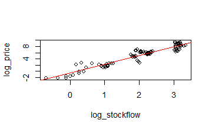

```r
plot(log_price ~ log_stockflow, data = sfdata)
abline(lnmodel, col='red') # fitted values
```

- Compute the OLS coefficients and their corresponding standard errors *

```r
Intercept <- rep(1, nrow(sfdata))
# Define the matrix X by joining the intercept term with the independent variable i.e, log_stockflow
X <- cbind(Intercept, sfdata$log_stockflow)
# Multiply the transpose of X to itself
XtX <- t(X) %*% X
# Compute the inverse of X
XtX_inv <- solve(XtX)
# Define the vector Y which denotes the dependent variable - log_price
Y <- sfdata$log_price
# Multiply the transpose of X with Y
XtY <- t(X) %*% Y
# Compute the estimates
beta <- XtX_inv %*% XtY
# Sigma represents the variance of the residuals
sigma <- var(lnmodel$residuals)
```

```r
var_beta <- sigma * XtX_inv
paste("The estimated coefficient is", round(beta[2],4))
```

```
[1] "The estimated coefficient is 2.8366"
```

```r
paste("The standard error of the above coefficient is",round(sqrt(var_beta[4]),4))
```

```
[1] "The standard error of the above coefficient is 0.0894"
```

```r
paste("The t-statistic for the above coefficient is",round(beta[2]/sqrt(var_beta[4]),4))
```

```
[1] "The t-statistic for the above coefficient is 31.7394"
```

```r
confint(lnmodel, "log_stockflow")
```

```
                 2.5 %   97.5 %
log_stockflow 2.658449 3.014654
```

*Since Market cap is a function of price calculated as Market cap = price x circulating supply, market cap is dependent vairable but since it is a funtion of price, it is evident that it will form a perfect linear regression model with very high r-square value which can create model biasness and which in turn could inflate the vairance of coefficients estimates and make the model unstable.*

*However, we can form a Multiregression model in order to study the relationship between stock_flow, price, active addressess and the market cap and prove a joint hypothesis i.e, what are the other factors along with the scarcity of bitcoin that are affecting the price of bitcoin keeping the price of bitcoin as a dependent variable consistently to maintain a stable model. We might exclude the marketcap from the joint hypothesis in order to maintain the stability of the model*

```r
Multilnmodel <- lm(log_price ~ log_stockflow + log_active_addresses + log_market_cap , data = sfdata)
summary(Multilnmodel)
```

```
Call:
lm(formula = log_price ~ log_stockflow + log_active_addresses +
    log_market_cap, data = sfdata)

Residuals:
     Min       1Q   Median       3Q      Max
-0.20876 -0.05008 -0.00444  0.03085  0.52110

Coefficients:
                      Estimate Std. Error t value Pr(>|t|)
(Intercept)          -14.00026    0.17293  -80.96  < 2e-16 ***
log_stockflow         -0.05900    0.04069   -1.45     0.15
log_active_addresses  -0.16419    0.02296   -7.15 1.39e-10 ***
log_market_cap         0.98828    0.01313   75.28  < 2e-16 ***
---
Signif. codes:  0 ‘***’ 0.001 ‘**’ 0.01 ‘*’ 0.05 ‘.’ 0.1 ‘ ’ 1

Residual standard error: 0.107 on 101 degrees of freedom
Multiple R-squared:  0.9988,    Adjusted R-squared:  0.9987
F-statistic: 2.77e+04 on 3 and 101 DF,  p-value: < 2.2e-16
```

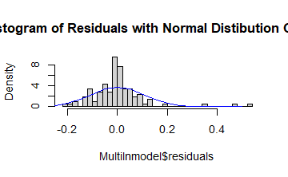

```r
hist(Multilnmodel$residuals, breaks = 30, freq = FALSE,
main = "Histogram of Residuals with Normal Distibution Overlay")
lines(seq(-1, 0.5, by=.05), dnorm(seq(-1, 0.5, by = .05), mean(Multilnmodel$residuals),
sd(Multilnmodel$residuals)), col="blue")
```

```
[1] 2 3
```

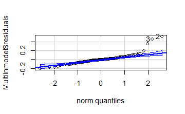

```r
qqPlot(Multilnmodel$residuals)
```

```r
# Jacque-Bera test for assessing Normality
# The null hypothesis is that the residuals are normally distributed
jarque.bera.test(Multilnmodel$residuals)
```

```
    Jarque Bera Test

data:  Multilnmodel$residuals
X-squared = 393.38, df = 2, p-value < 2.2e-16
```

```r
linearHypothesis(Multilnmodel, c("log_stockflow = 0","log_active_addresses = 0","log_market_cap=0"))
```

```
Linear hypothesis test

Hypothesis:
log_stockflow = 0
log_active_addresses = 0
log_market_cap = 0

Model 1: restricted model
Model 2: log_price ~ log_stockflow + log_active_addresses + log_market_cap

  Res.Df    RSS Df Sum of Sq     F    Pr(>F)
1    104 952.66
2    101   1.16  3    951.51 27697 < 2.2e-16 ***
---
Signif. codes:  0 ‘***’ 0.001 ‘**’ 0.01 ‘*’ 0.05 ‘.’ 0.1 ‘ ’ 1
```

- We can test the model stability and try to improve the model by removing the market cap since market cap in itself is a function of price as discussed before and could be effecting the model predictability *

```r
updatedmultilnmodel <- lm(log_price ~ log_stockflow + log_active_addresses , data = sfdata)
summary(updatedmultilnmodel)
```

```
Call:
lm(formula = log_price ~ log_stockflow + log_active_addresses,
    data = sfdata)

Residuals:
     Min       1Q   Median       3Q      Max
-1.48054 -0.64688 -0.04378  0.65595  2.24534

Coefficients:
                     Estimate Std. Error t value Pr(>|t|)
(Intercept)           -7.2081     1.1094  -6.497 3.04e-09 ***
log_stockflow          1.2511     0.2766   4.523 1.65e-05 ***
log_active_addresses   0.8396     0.1406   5.972 3.44e-08 ***
---
Signif. codes:  0 ‘***’ 0.001 ‘**’ 0.01 ‘*’ 0.05 ‘.’ 0.1 ‘ ’ 1

Residual standard error: 0.8047 on 102 degrees of freedom
Multiple R-squared:  0.9307,    Adjusted R-squared:  0.9293
F-statistic: 684.6 on 2 and 102 DF,  p-value: < 2.2e-16
```

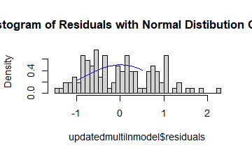

```r
hist(updatedmultilnmodel$residuals, breaks = 30, freq = FALSE,
main = "Histogram of Residuals with Normal Distibution Overlay")
lines(seq(-1, 0.5, by=.05), dnorm(seq(-1, 0.5, by = .05), mean(updatedmultilnmodel$residuals),
sd(updatedmultilnmodel$residuals)), col="blue")
```

```
[1] 41 43
```

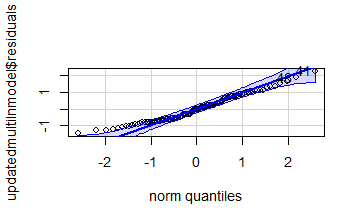

```r
qqPlot(updatedmultilnmodel$residuals)
```

```r
# Jacque-Bera test for assessing Normality
# The null hypothesis is that the residuals are normally distributed
jarque.bera.test(updatedmultilnmodel$residuals)
```

```
    Jarque Bera Test

data:  updatedmultilnmodel$residuals
X-squared = 4.3089, df = 2, p-value = 0.116
```

Test the joint hypothesis that the coefficients of the two variables are all zero i.e., H0 : β1 = β2 = 0

```r
linearHypothesis(updatedmultilnmodel, c("log_stockflow = 0","log_active_addresses = 0"))
```

```
Linear hypothesis test

Hypothesis:
log_stockflow = 0
log_active_addresses = 0

Model 1: restricted model
Model 2: log_price ~ log_stockflow + log_active_addresses

  Res.Df    RSS Df Sum of Sq      F    Pr(>F)
1    104 952.66
2    102  66.05  2    886.61 684.59 < 2.2e-16 ***
---
Signif. codes:  0 ‘***’ 0.001 ‘**’ 0.01 ‘*’ 0.05 ‘.’ 0.1 ‘ ’ 1
```

```r
mean(sfdata$log_price)
```

```
[1] 5.066617
```

```r
mean(updatedmultilnmodel$fitted.values)
```

```
[1] 5.066617
```

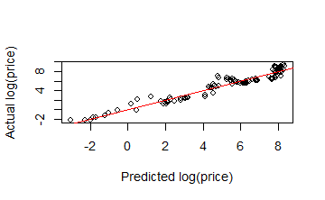

```r
# Plot of predicted vs actual values
plot(updatedmultilnmodel$fitted.values, sfdata$log_price,
     xlim = c(min(updatedmultilnmodel$fitted.values), max(updatedmultilnmodel$fitted.values)),
     ylim = c(min(sfdata$log_price), max(sfdata$log_price)),
     xlab = "Predicted log(price)", ylab = "Actual log(price)")
abline(0, 1, col = "red")
```

- Incorporate higher order terms of the predicted values into the specification *

```r
sfdata$fits <- updatedmultilnmodel$fitted.values
sfdata$fits2 <- (sfdata$fits)^2
sfdata$fits3 <- (sfdata$fits)^3
updatedmultilnmodel_d <- lm(log_price ~ log_stockflow + log_active_addresses + fits2 + fits3, data = sfdata)
summary(updatedmultilnmodel_d)
```

```
Call:
lm(formula = log_price ~ log_stockflow + log_active_addresses +
    fits2 + fits3, data = sfdata)

Residuals:
    Min      1Q  Median      3Q     Max
-1.3184 -0.6420 -0.1103  0.6783  2.4333

Coefficients:
                      Estimate Std. Error t value Pr(>|t|)
(Intercept)          -7.464450   1.146327  -6.512 3.01e-09 ***
log_stockflow         0.800287   0.384942   2.079   0.0402 *
log_active_addresses  0.898797   0.151619   5.928 4.39e-08 ***
fits2                 0.007094   0.031227   0.227   0.8208
fits3                 0.001010   0.003084   0.327   0.7441
---
Signif. codes:  0 ‘***’ 0.001 ‘**’ 0.01 ‘*’ 0.05 ‘.’ 0.1 ‘ ’ 1

Residual standard error: 0.8013 on 100 degrees of freedom
Multiple R-squared:  0.9326,    Adjusted R-squared:  0.9299
F-statistic: 345.9 on 4 and 100 DF,  p-value: < 2.2e-16
```

- regression residuals/errors *

```r
mean(updatedmultilnmodel$residuals)
```

```
[1] 6.245005e-17
```

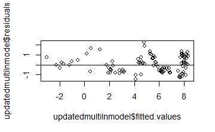

```r
plot(updatedmultilnmodel$fitted.values, updatedmultilnmodel$residuals)
abline(0,0)
```

- White test: *

```r
sfdata$residuals2 <- (updatedmultilnmodel$residuals)^2  # Correcting the calculation of squared residuals
Multilnmodel_W <- lm(residuals2 ~ log_stockflow + log_active_addresses +
                     I(log_stockflow^2) + I(log_active_addresses^2) +
                     log_stockflow * log_active_addresses, data = sfdata)
summary(Multilnmodel_W)
```

```
Call:
lm(formula = residuals2 ~ log_stockflow + log_active_addresses +
    I(log_stockflow^2) + I(log_active_addresses^2) + log_stockflow *
    log_active_addresses, data = sfdata)

Residuals:
    Min      1Q  Median      3Q     Max
-1.1300 -0.4081 -0.1341  0.2389  4.4071

Coefficients:
                                   Estimate Std. Error t value Pr(>|t|)
(Intercept)                          3.9808    12.3745   0.322    0.748
log_stockflow                        5.5308     6.3533   0.871    0.386
log_active_addresses                -1.3973     3.2088  -0.435    0.664
I(log_stockflow^2)                   1.1061     0.8059   1.372    0.173
I(log_active_addresses^2)            0.1236     0.2066   0.598    0.551
log_stockflow:log_active_addresses  -0.8313     0.8141  -1.021    0.310

Residual standard error: 0.7547 on 99 degrees of freedom
Multiple R-squared:  0.0783,    Adjusted R-squared:  0.03174
F-statistic: 1.682 on 5 and 99 DF,  p-value: 0.146
```

```r
RSQ <- summary(Multilnmodel_W)$r.squared
tstat <- nobs(updatedmultilnmodel)*RSQ
```

- heteroscedasticity *

```r
nbetas <- summary(Multilnmodel_W)$df[1]
# Compute the p value
pval <- 1 - pchisq(tstat, nbetas-1)
# An alternative to White's test - The Breusch-Pagan test
paste("The test statistic for White's test is", round(tstat,2), "with p value",
round(pval,8))
```

```
[1] "The test statistic for White's test is 8.22 with p value 0.14446656"
```

```r
bptest(updatedmultilnmodel)
```

```
    studentized Breusch-Pagan test

data:  updatedmultilnmodel
BP = 1.011, df = 2, p-value = 0.6032
```